# Mengunggah file dari komputer lokal ke lingkungan Colab

```python
from google.colab import files
uploaded = files.upload()
```

Upload widget is only available when the cell has been executed in the current browser session. Please rerun this cell to enable.

```
Saving Vehicle Detection.v2i.yolov8.zip to Vehicle Detection.v2i.yolov8.zip
```

Setelah dijalankan, pengguna bisa memilih file dari perangkat mereka, dan file tersebut akan tersedia untuk diproses di notebook.

# Mengekstrak file ZIP

```python
!unzip "Vehicle Detection.v2i.yolov8.zip" -d "vehicle_dataset"
```

[output not shown]

[output cut: 1958 more lines]

[output not shown]

Digunakan untuk mengekstrak file ZIP bernama Vehicle Detection.v2i.yolov8.zip ke dalam folder bernama vehicle_dataset di Google Colab.

# Menginstal library Ultralytics

```python
!pip install ultralytics
```

[output not shown]

[output cut: 8 more lines]

[output not shown]

Digunakan untuk menginstal library Ultralytics, yang berisi tools seperti YOLOv8 untuk pendeteksian objek dan computer vision di Google Colab.

# Training Model

```python
from ultralytics import YOLO

# Load model YOLOv8n (versi ringan)
model = YOLO("yolov8n.pt")

# Mulai training
model.train(data="vehicle_dataset/data.yaml", epochs=50, imgsz=640)
```

```
Creating new Ultralytics Settings v0.0.6 file ✅
View Ultralytics Settings with 'yolo settings' or at '/root/.config/Ultralytics/settings.json'
Update Settings with 'yolo settings key=value', i.e. 'yolo settings runs_dir=path/to/dir'. For help see https://docs.ultralytics.com/quickstart/#ultralytics-settings.
Downloading https://github.com/ultralytics/assets/releases/download/v8.3.0/yolov8n.pt to 'yolov8n.pt'...
```

```
Ultralytics 8.3.152 🚀 Python-3.11.13 torch-2.6.0+cu124 CUDA:0 (Tesla T4, 15095MiB)
engine/trainer: agnostic_nms=False, amp=True, augment=False, auto_augment=randaugment, batch=16, bgr=0.0, box=7.5, cache=False, cfg=None, classes=None, close_mosaic=10, cls=0.5, conf=None, copy_paste=0.0, copy_paste_mode=flip, cos_lr=False, cutmix=0.0, data=vehicle_dataset/data.yaml, degrees=0.0, de…
Downloading https://ultralytics.com/assets/Arial.ttf to '/root/.config/Ultralytics/Arial.ttf'...
```

```
Overriding model.yaml nc=80 with nc=4

                   from  n    params  module                                       arguments
  0                  -1  1       464  ultralytics.nn.modules.conv.Conv             [3, 16, 3, 2]
  1                  -1  1      4672  ultralytics.nn.modules.conv.Conv             [16, 32, 3, 2]
  2                  -1  1      7360  ultralytics.nn.modules.block.C2f             [32, 32, 1, True]
  3                  -1  1     18560  ultralytics.nn.modules.conv.Conv             [32, 64, 3, 2]
  4                  -1  2     49664  ultralytics.nn.modules.block.C2f             [64, 64, 2, True]
  5                  -1  1     73984  ultralytics.nn.modules.conv.Conv             [64, 128, 3, 2]
  6                  -1  2    197632  ultralytics.nn.modules.block.C2f             [128, 128, 2, True]
  7                  -1  1    295424  ultralytics.nn.modules.conv.Conv             [128, 256, 3, 2]
  8                  -1  1    460288  ultralytics.nn.modules.block.C2f             [256, 256, 1, True]
  9                  -1  1    164608  ultralytics.nn.modules.block.SPPF            [256, 256, 5]
 10                  -1  1         0  torch.nn.modules.upsampling.Upsample         [None, 2, 'nearest']
 11             [-1, 6]  1         0  ultralytics.nn.modules.conv.Concat           [1]
 12                  -1  1    148224  ultralytics.nn.modules.block.C2f             [384, 128, 1]
 13                  -1  1         0  torch.nn.modules.upsampling.Upsample         [None, 2, 'nearest']
 14             [-1, 4]  1         0  ultralytics.nn.modules.conv.Concat           [1]
 15                  -1  1     37248  ultralytics.nn.modules.block.C2f             [192, 64, 1]
 16                  -1  1     36992  ultralytics.nn.modules.conv.Conv             [64, 64, 3, 2]
 17            [-1, 12]  1         0  ultralytics.nn.modules.conv.Concat           [1]
 18                  -1  1    123648  ultralytics.nn.modules.block.C2f             [192, 128, 1]
 19                  -1  1    147712  ultralytics.nn.modules.conv.Conv             [128, 128, 3, 2]
 20             [-1, 9]  1         0  ultralytics.nn.modules.conv.Concat           [1]
 21                  -1  1    493056  ultralytics.nn.modules.block.C2f             [384, 256, 1]
 22        [15, 18, 21]  1    752092  ultralytics.nn.modules.head.Detect           [4, [64, 128, 256]]
```

```
Model summary: 129 layers, 3,011,628 parameters, 3,011,612 gradients, 8.2 GFLOPs

Transferred 319/355 items from pretrained weights
Freezing layer 'model.22.dfl.conv.weight'
AMP: running Automatic Mixed Precision (AMP) checks...
Downloading https://github.com/ultralytics/assets/releases/download/v8.3.0/yolo11n.pt to 'yolo11n.pt'...
```

```
AMP: checks passed ✅
train: Fast image access ✅ (ping: 0.0±0.0 ms, read: 99.2±160.3 MB/s, size: 77.3 KB)
```

```
train: Scanning /content/vehicle_dataset/train/labels... 800 images, 0 backgrounds, 0 corrupt: 100%|██████████| 800/800 [00:01<00:00, 601.60it/s]
```

```
train: New cache created: /content/vehicle_dataset/train/labels.cache
```

```
albumentations: Blur(p=0.01, blur_limit=(3, 7)), MedianBlur(p=0.01, blur_limit=(3, 7)), ToGray(p=0.01, method='weighted_average', num_output_channels=3), CLAHE(p=0.01, clip_limit=(1.0, 4.0), tile_grid_size=(8, 8))
val: Fast image access ✅ (ping: 0.0±0.0 ms, read: 53.5±33.5 MB/s, size: 95.6 KB)
```

```
val: Scanning /content/vehicle_dataset/valid/labels... 100 images, 0 backgrounds, 0 corrupt: 100%|██████████| 100/100 [00:00<00:00, 437.33it/s]
```

```
val: New cache created: /content/vehicle_dataset/valid/labels.cache
```

```
Plotting labels to runs/detect/train/labels.jpg...
optimizer: 'optimizer=auto' found, ignoring 'lr0=0.01' and 'momentum=0.937' and determining best 'optimizer', 'lr0' and 'momentum' automatically...
optimizer: AdamW(lr=0.00125, momentum=0.9) with parameter groups 57 weight(decay=0.0), 64 weight(decay=0.0005), 63 bias(decay=0.0)
Image sizes 640 train, 640 val
Using 2 dataloader workers
Logging results to runs/detect/train
Starting training for 50 epochs...

      Epoch    GPU_mem   box_loss   cls_loss   dfl_loss  Instances       Size
```

```
       1/50      2.42G      1.559      2.494      1.273        310        640: 100%|██████████| 50/50 [00:16<00:00,  3.06it/s]
                 Class     Images  Instances      Box(P          R      mAP50  mAP50-95): 100%|██████████| 4/4 [00:02<00:00,  1.85it/s]
```

```
                   all        100       1107      0.656      0.112      0.296      0.209
```

```
      Epoch    GPU_mem   box_loss   cls_loss   dfl_loss  Instances       Size
```

```
       2/50       2.6G      1.333      1.411      1.136        237        640: 100%|██████████| 50/50 [00:13<00:00,  3.80it/s]
                 Class     Images  Instances      Box(P          R      mAP50  mAP50-95): 100%|██████████| 4/4 [00:01<00:00,  3.48it/s]
```

```
                   all        100       1107      0.616       0.51      0.614      0.436
```

```
      Epoch    GPU_mem   box_loss   cls_loss   dfl_loss  Instances       Size
```

```
       3/50      2.62G      1.257      1.249      1.103        185        640: 100%|██████████| 50/50 [00:12<00:00,  3.85it/s]
                 Class     Images  Instances      Box(P          R      mAP50  mAP50-95): 100%|██████████| 4/4 [00:01<00:00,  3.34it/s]
```

```
                   all        100       1107      0.679      0.628      0.688       0.46
```

```
      Epoch    GPU_mem   box_loss   cls_loss   dfl_loss  Instances       Size
```

```
       4/50      2.63G      1.258      1.161      1.107        270        640: 100%|██████████| 50/50 [00:14<00:00,  3.56it/s]
                 Class     Images  Instances      Box(P          R      mAP50  mAP50-95): 100%|██████████| 4/4 [00:01<00:00,  3.61it/s]
```

```
                   all        100       1107      0.722      0.615      0.734      0.491
```

```
      Epoch    GPU_mem   box_loss   cls_loss   dfl_loss  Instances       Size
```

```
       5/50      2.65G      1.209      1.078      1.074        341        640: 100%|██████████| 50/50 [00:12<00:00,  3.89it/s]
                 Class     Images  Instances      Box(P          R      mAP50  mAP50-95): 100%|██████████| 4/4 [00:01<00:00,  3.10it/s]
```

```
                   all        100       1107      0.795       0.72      0.789      0.564
```

```
      Epoch    GPU_mem   box_loss   cls_loss   dfl_loss  Instances       Size
```

```
       6/50      2.67G       1.18      1.033      1.067        199        640: 100%|██████████| 50/50 [00:13<00:00,  3.79it/s]
                 Class     Images  Instances      Box(P          R      mAP50  mAP50-95): 100%|██████████| 4/4 [00:01<00:00,  2.12it/s]
```

```
                   all        100       1107      0.788      0.655      0.762      0.538
```

```
      Epoch    GPU_mem   box_loss   cls_loss   dfl_loss  Instances       Size
```

```
       7/50      2.68G      1.151     0.9982      1.061        272        640: 100%|██████████| 50/50 [00:12<00:00,  3.88it/s]
                 Class     Images  Instances      Box(P          R      mAP50  mAP50-95): 100%|██████████| 4/4 [00:01<00:00,  3.45it/s]
```

```
                   all        100       1107      0.775      0.746      0.827      0.601
```

```
      Epoch    GPU_mem   box_loss   cls_loss   dfl_loss  Instances       Size
```

```
       8/50       2.7G      1.142      0.948      1.059        243        640: 100%|██████████| 50/50 [00:13<00:00,  3.76it/s]
                 Class     Images  Instances      Box(P          R      mAP50  mAP50-95): 100%|██████████| 4/4 [00:01<00:00,  3.97it/s]
```

```
                   all        100       1107      0.852      0.748      0.848      0.616
```

```
      Epoch    GPU_mem   box_loss   cls_loss   dfl_loss  Instances       Size
```

```
       9/50      2.72G      1.099     0.9047      1.043        179        640: 100%|██████████| 50/50 [00:12<00:00,  3.88it/s]
                 Class     Images  Instances      Box(P          R      mAP50  mAP50-95): 100%|██████████| 4/4 [00:01<00:00,  3.94it/s]
```

```
                   all        100       1107      0.847      0.757      0.862      0.648
```

```
      Epoch    GPU_mem   box_loss   cls_loss   dfl_loss  Instances       Size
```

```
      10/50       2.9G      1.087     0.8739      1.035        280        640: 100%|██████████| 50/50 [00:13<00:00,  3.80it/s]
                 Class     Images  Instances      Box(P          R      mAP50  mAP50-95): 100%|██████████| 4/4 [00:01<00:00,  3.73it/s]
```

```
                   all        100       1107      0.815      0.777      0.855      0.634
```

```
      Epoch    GPU_mem   box_loss   cls_loss   dfl_loss  Instances       Size
```

```
      11/50      2.92G      1.103      0.869      1.042        171        640: 100%|██████████| 50/50 [00:13<00:00,  3.81it/s]
                 Class     Images  Instances      Box(P          R      mAP50  mAP50-95): 100%|██████████| 4/4 [00:00<00:00,  4.00it/s]
```

```
                   all        100       1107      0.809       0.77      0.861      0.639
```

```
      Epoch    GPU_mem   box_loss   cls_loss   dfl_loss  Instances       Size
```

```
      12/50      2.93G      1.081     0.8397       1.03        316        640: 100%|██████████| 50/50 [00:13<00:00,  3.81it/s]
                 Class     Images  Instances      Box(P          R      mAP50  mAP50-95): 100%|██████████| 4/4 [00:01<00:00,  3.88it/s]
```

```
                   all        100       1107      0.862      0.755      0.865      0.653
```

```
      Epoch    GPU_mem   box_loss   cls_loss   dfl_loss  Instances       Size
```

```
      13/50      2.95G      1.046      0.809       1.02        238        640: 100%|██████████| 50/50 [00:12<00:00,  3.88it/s]
                 Class     Images  Instances      Box(P          R      mAP50  mAP50-95): 100%|██████████| 4/4 [00:01<00:00,  2.63it/s]
```

```
                   all        100       1107      0.802      0.762      0.842      0.623
```

```
      Epoch    GPU_mem   box_loss   cls_loss   dfl_loss  Instances       Size
```

```
      14/50      2.97G      1.056     0.8127      1.028        344        640: 100%|██████████| 50/50 [00:12<00:00,  3.99it/s]
                 Class     Images  Instances      Box(P          R      mAP50  mAP50-95): 100%|██████████| 4/4 [00:01<00:00,  2.14it/s]
```

```
                   all        100       1107      0.831      0.796      0.865      0.644
```

```
      Epoch    GPU_mem   box_loss   cls_loss   dfl_loss  Instances       Size
```

```
      15/50      2.98G      1.041     0.7789      1.016        220        640: 100%|██████████| 50/50 [00:13<00:00,  3.79it/s]
                 Class     Images  Instances      Box(P          R      mAP50  mAP50-95): 100%|██████████| 4/4 [00:01<00:00,  3.49it/s]
```

```
                   all        100       1107       0.83      0.765      0.884      0.657
```

```
      Epoch    GPU_mem   box_loss   cls_loss   dfl_loss  Instances       Size
```

```
      16/50      3.19G      1.035     0.7714      1.012        301        640: 100%|██████████| 50/50 [00:12<00:00,  3.88it/s]
                 Class     Images  Instances      Box(P          R      mAP50  mAP50-95): 100%|██████████| 4/4 [00:01<00:00,  3.63it/s]
```

```
                   all        100       1107      0.863      0.761      0.852      0.655
```

```
      Epoch    GPU_mem   box_loss   cls_loss   dfl_loss  Instances       Size
```

```
      17/50       3.2G      1.037     0.7748      1.017        287        640: 100%|██████████| 50/50 [00:12<00:00,  3.87it/s]
                 Class     Images  Instances      Box(P          R      mAP50  mAP50-95): 100%|██████████| 4/4 [00:01<00:00,  3.28it/s]
```

```
                   all        100       1107      0.856       0.83      0.897      0.688
```

```
      Epoch    GPU_mem   box_loss   cls_loss   dfl_loss  Instances       Size
```

```
      18/50      3.22G       1.03     0.7486      1.004        306        640: 100%|██████████| 50/50 [00:13<00:00,  3.84it/s]
                 Class     Images  Instances      Box(P          R      mAP50  mAP50-95): 100%|██████████| 4/4 [00:01<00:00,  3.75it/s]
```

```
                   all        100       1107      0.824      0.815      0.874      0.667
```

```
      Epoch    GPU_mem   box_loss   cls_loss   dfl_loss  Instances       Size
```

```
      19/50      3.24G      1.021     0.7387      1.002        208        640: 100%|██████████| 50/50 [00:12<00:00,  3.93it/s]
                 Class     Images  Instances      Box(P          R      mAP50  mAP50-95): 100%|██████████| 4/4 [00:01<00:00,  3.31it/s]
```

```
                   all        100       1107      0.866      0.809      0.896        0.7
```

```
      Epoch    GPU_mem   box_loss   cls_loss   dfl_loss  Instances       Size
```

```
      20/50      3.25G      0.992     0.7211     0.9977        231        640: 100%|██████████| 50/50 [00:12<00:00,  3.86it/s]
                 Class     Images  Instances      Box(P          R      mAP50  mAP50-95): 100%|██████████| 4/4 [00:01<00:00,  3.74it/s]
```

```
                   all        100       1107      0.842       0.85      0.892      0.677
```

```
      Epoch    GPU_mem   box_loss   cls_loss   dfl_loss  Instances       Size
```

```
      21/50      3.27G     0.9957     0.7123      1.001        382        640: 100%|██████████| 50/50 [00:13<00:00,  3.80it/s]
                 Class     Images  Instances      Box(P          R      mAP50  mAP50-95): 100%|██████████| 4/4 [00:01<00:00,  2.59it/s]
```

```
                   all        100       1107      0.887      0.832      0.897      0.689
```

```
      Epoch    GPU_mem   box_loss   cls_loss   dfl_loss  Instances       Size
```

```
      22/50       3.5G     0.9865      0.696     0.9929        176        640: 100%|██████████| 50/50 [00:12<00:00,  3.95it/s]
                 Class     Images  Instances      Box(P          R      mAP50  mAP50-95): 100%|██████████| 4/4 [00:01<00:00,  2.23it/s]
```

```
                   all        100       1107      0.858      0.865      0.911      0.704
```

```
      Epoch    GPU_mem   box_loss   cls_loss   dfl_loss  Instances       Size
```

```
      23/50      3.51G      0.974     0.6883     0.9872        267        640: 100%|██████████| 50/50 [00:13<00:00,  3.82it/s]
                 Class     Images  Instances      Box(P          R      mAP50  mAP50-95): 100%|██████████| 4/4 [00:01<00:00,  3.80it/s]
```

```
                   all        100       1107      0.856      0.867      0.915      0.704
```

```
      Epoch    GPU_mem   box_loss   cls_loss   dfl_loss  Instances       Size
```

```
      24/50      3.53G     0.9947     0.6959     0.9915        310        640: 100%|██████████| 50/50 [00:13<00:00,  3.80it/s]
                 Class     Images  Instances      Box(P          R      mAP50  mAP50-95): 100%|██████████| 4/4 [00:01<00:00,  3.80it/s]
```

```
                   all        100       1107       0.91      0.847      0.914      0.718
```

```
      Epoch    GPU_mem   box_loss   cls_loss   dfl_loss  Instances       Size
```

```
      25/50      3.54G     0.9773     0.6763     0.9812        284        640: 100%|██████████| 50/50 [00:13<00:00,  3.79it/s]
                 Class     Images  Instances      Box(P          R      mAP50  mAP50-95): 100%|██████████| 4/4 [00:01<00:00,  3.79it/s]
```

```
                   all        100       1107      0.886      0.845      0.907      0.711
```

```
      Epoch    GPU_mem   box_loss   cls_loss   dfl_loss  Instances       Size
```

```
      26/50      3.56G     0.9577     0.6661      0.981        286        640: 100%|██████████| 50/50 [00:13<00:00,  3.76it/s]
                 Class     Images  Instances      Box(P          R      mAP50  mAP50-95): 100%|██████████| 4/4 [00:00<00:00,  4.03it/s]
```

```
                   all        100       1107      0.884      0.846      0.912      0.711
```

```
      Epoch    GPU_mem   box_loss   cls_loss   dfl_loss  Instances       Size
```

```
      27/50      3.58G     0.9484     0.6661     0.9736        357        640: 100%|██████████| 50/50 [00:12<00:00,  3.87it/s]
                 Class     Images  Instances      Box(P          R      mAP50  mAP50-95): 100%|██████████| 4/4 [00:01<00:00,  3.80it/s]
```

```
                   all        100       1107      0.914      0.808      0.914      0.718
```

```
      Epoch    GPU_mem   box_loss   cls_loss   dfl_loss  Instances       Size
```

```
      28/50       3.6G     0.9648     0.6627     0.9858        257        640: 100%|██████████| 50/50 [00:12<00:00,  3.85it/s]
                 Class     Images  Instances      Box(P          R      mAP50  mAP50-95): 100%|██████████| 4/4 [00:01<00:00,  3.63it/s]
```

```
                   all        100       1107      0.889      0.847       0.92      0.725
```

```
      Epoch    GPU_mem   box_loss   cls_loss   dfl_loss  Instances       Size
```

```
      29/50      3.61G     0.9389     0.6571     0.9745        315        640: 100%|██████████| 50/50 [00:13<00:00,  3.78it/s]
                 Class     Images  Instances      Box(P          R      mAP50  mAP50-95): 100%|██████████| 4/4 [00:01<00:00,  2.13it/s]
```

```
                   all        100       1107      0.876      0.846      0.905      0.706
```

```
      Epoch    GPU_mem   box_loss   cls_loss   dfl_loss  Instances       Size
```

```
      30/50      3.63G     0.9524     0.6459     0.9746        248        640: 100%|██████████| 50/50 [00:13<00:00,  3.78it/s]
                 Class     Images  Instances      Box(P          R      mAP50  mAP50-95): 100%|██████████| 4/4 [00:01<00:00,  3.99it/s]
```

```
                   all        100       1107      0.913      0.833      0.915      0.714
```

```
      Epoch    GPU_mem   box_loss   cls_loss   dfl_loss  Instances       Size
```

```
      31/50      3.65G     0.9466     0.6328     0.9759        309        640: 100%|██████████| 50/50 [00:12<00:00,  3.94it/s]
                 Class     Images  Instances      Box(P          R      mAP50  mAP50-95): 100%|██████████| 4/4 [00:01<00:00,  3.44it/s]
```

```
                   all        100       1107      0.905      0.871      0.921      0.734
```

```
      Epoch    GPU_mem   box_loss   cls_loss   dfl_loss  Instances       Size
```

```
      32/50      3.67G     0.9186     0.6175     0.9697        253        640: 100%|██████████| 50/50 [00:12<00:00,  3.92it/s]
                 Class     Images  Instances      Box(P          R      mAP50  mAP50-95): 100%|██████████| 4/4 [00:01<00:00,  3.47it/s]
```

```
                   all        100       1107        0.9      0.859      0.915       0.71
```

```
      Epoch    GPU_mem   box_loss   cls_loss   dfl_loss  Instances       Size
```

```
      33/50      3.68G     0.9313     0.6224     0.9679        201        640: 100%|██████████| 50/50 [00:12<00:00,  3.90it/s]
                 Class     Images  Instances      Box(P          R      mAP50  mAP50-95): 100%|██████████| 4/4 [00:01<00:00,  3.28it/s]
```

```
                   all        100       1107      0.911      0.851       0.92      0.727
```

```
      Epoch    GPU_mem   box_loss   cls_loss   dfl_loss  Instances       Size
```

```
      34/50       3.7G     0.9381     0.6218      0.972        294        640: 100%|██████████| 50/50 [00:13<00:00,  3.84it/s]
                 Class     Images  Instances      Box(P          R      mAP50  mAP50-95): 100%|██████████| 4/4 [00:01<00:00,  3.62it/s]
```

```
                   all        100       1107      0.888       0.88      0.929       0.74
```

```
      Epoch    GPU_mem   box_loss   cls_loss   dfl_loss  Instances       Size
```

```
      35/50      3.72G     0.9067      0.608     0.9639        289        640: 100%|██████████| 50/50 [00:12<00:00,  3.93it/s]
                 Class     Images  Instances      Box(P          R      mAP50  mAP50-95): 100%|██████████| 4/4 [00:01<00:00,  3.37it/s]
```

```
                   all        100       1107      0.905      0.848      0.923       0.73
```

```
      Epoch    GPU_mem   box_loss   cls_loss   dfl_loss  Instances       Size
```

```
      36/50      3.73G     0.9164     0.6026     0.9619        304        640: 100%|██████████| 50/50 [00:13<00:00,  3.83it/s]
                 Class     Images  Instances      Box(P          R      mAP50  mAP50-95): 100%|██████████| 4/4 [00:01<00:00,  3.75it/s]
```

```
                   all        100       1107      0.901      0.857      0.923      0.731
```

```
      Epoch    GPU_mem   box_loss   cls_loss   dfl_loss  Instances       Size
```

```
      37/50      3.75G     0.9107     0.6017       0.96        288        640: 100%|██████████| 50/50 [00:13<00:00,  3.81it/s]
                 Class     Images  Instances      Box(P          R      mAP50  mAP50-95): 100%|██████████| 4/4 [00:01<00:00,  2.43it/s]
```

```
                   all        100       1107       0.89      0.862      0.926      0.743
```

```
      Epoch    GPU_mem   box_loss   cls_loss   dfl_loss  Instances       Size
```

```
      38/50      3.77G     0.8953     0.5899     0.9596        229        640: 100%|██████████| 50/50 [00:12<00:00,  3.90it/s]
                 Class     Images  Instances      Box(P          R      mAP50  mAP50-95): 100%|██████████| 4/4 [00:01<00:00,  2.88it/s]
```

```
                   all        100       1107      0.887       0.88      0.927      0.737
```

```
      Epoch    GPU_mem   box_loss   cls_loss   dfl_loss  Instances       Size
```

```
      39/50      3.78G     0.8977      0.593     0.9557        241        640: 100%|██████████| 50/50 [00:12<00:00,  3.90it/s]
                 Class     Images  Instances      Box(P          R      mAP50  mAP50-95): 100%|██████████| 4/4 [00:01<00:00,  3.46it/s]
```

```
                   all        100       1107       0.91      0.872      0.925      0.738
```

```
      Epoch    GPU_mem   box_loss   cls_loss   dfl_loss  Instances       Size
```

```
      40/50       3.8G     0.8869     0.5791     0.9509        276        640: 100%|██████████| 50/50 [00:13<00:00,  3.79it/s]
                 Class     Images  Instances      Box(P          R      mAP50  mAP50-95): 100%|██████████| 4/4 [00:01<00:00,  3.94it/s]
```

```
                   all        100       1107      0.907      0.877      0.934      0.743
```

```
Closing dataloader mosaic
albumentations: Blur(p=0.01, blur_limit=(3, 7)), MedianBlur(p=0.01, blur_limit=(3, 7)), ToGray(p=0.01, method='weighted_average', num_output_channels=3), CLAHE(p=0.01, clip_limit=(1.0, 4.0), tile_grid_size=(8, 8))

      Epoch    GPU_mem   box_loss   cls_loss   dfl_loss  Instances       Size
```

```
      41/50      3.82G      0.887     0.5559     0.9457        168        640: 100%|██████████| 50/50 [00:14<00:00,  3.53it/s]
                 Class     Images  Instances      Box(P          R      mAP50  mAP50-95): 100%|██████████| 4/4 [00:01<00:00,  3.85it/s]
```

```
                   all        100       1107      0.887      0.877      0.929      0.736
```

```
      Epoch    GPU_mem   box_loss   cls_loss   dfl_loss  Instances       Size
```

```
      42/50      3.84G     0.8823      0.546      0.945        186        640: 100%|██████████| 50/50 [00:12<00:00,  4.04it/s]
                 Class     Images  Instances      Box(P          R      mAP50  mAP50-95): 100%|██████████| 4/4 [00:01<00:00,  3.83it/s]
```

```
                   all        100       1107      0.906      0.865      0.929      0.736
```

```
      Epoch    GPU_mem   box_loss   cls_loss   dfl_loss  Instances       Size
```

```
      43/50      3.85G     0.8766     0.5439     0.9413        200        640: 100%|██████████| 50/50 [00:12<00:00,  4.07it/s]
                 Class     Images  Instances      Box(P          R      mAP50  mAP50-95): 100%|██████████| 4/4 [00:01<00:00,  3.80it/s]
```

```
                   all        100       1107      0.914      0.872      0.936      0.747
```

```
      Epoch    GPU_mem   box_loss   cls_loss   dfl_loss  Instances       Size
```

```
      44/50      3.87G     0.8724     0.5322     0.9399        138        640: 100%|██████████| 50/50 [00:12<00:00,  4.03it/s]
                 Class     Images  Instances      Box(P          R      mAP50  mAP50-95): 100%|██████████| 4/4 [00:01<00:00,  3.68it/s]
```

```
                   all        100       1107      0.905      0.881      0.935       0.75
```

```
      Epoch    GPU_mem   box_loss   cls_loss   dfl_loss  Instances       Size
```

```
      45/50      3.89G     0.8558     0.5207     0.9339        172        640: 100%|██████████| 50/50 [00:12<00:00,  4.06it/s]
                 Class     Images  Instances      Box(P          R      mAP50  mAP50-95): 100%|██████████| 4/4 [00:00<00:00,  4.07it/s]
```

```
                   all        100       1107       0.92      0.867      0.938      0.758
```

```
      Epoch    GPU_mem   box_loss   cls_loss   dfl_loss  Instances       Size
```

```
      46/50       3.9G     0.8519     0.5156     0.9282        151        640: 100%|██████████| 50/50 [00:12<00:00,  4.08it/s]
                 Class     Images  Instances      Box(P          R      mAP50  mAP50-95): 100%|██████████| 4/4 [00:01<00:00,  2.99it/s]
```

```
                   all        100       1107      0.905      0.876      0.938      0.759
```

```
      Epoch    GPU_mem   box_loss   cls_loss   dfl_loss  Instances       Size
```

```
      47/50      3.92G     0.8594     0.5155     0.9333        191        640: 100%|██████████| 50/50 [00:12<00:00,  4.08it/s]
                 Class     Images  Instances      Box(P          R      mAP50  mAP50-95): 100%|██████████| 4/4 [00:01<00:00,  2.55it/s]
```

```
                   all        100       1107        0.9      0.889      0.936      0.757
```

```
      Epoch    GPU_mem   box_loss   cls_loss   dfl_loss  Instances       Size
```

```
      48/50      3.94G     0.8504     0.5129     0.9326        172        640: 100%|██████████| 50/50 [00:12<00:00,  4.03it/s]
                 Class     Images  Instances      Box(P          R      mAP50  mAP50-95): 100%|██████████| 4/4 [00:01<00:00,  3.93it/s]
```

```
                   all        100       1107      0.922      0.872      0.939      0.754
```

```
      Epoch    GPU_mem   box_loss   cls_loss   dfl_loss  Instances       Size
```

```
      49/50      3.96G     0.8359     0.5022      0.927        177        640: 100%|██████████| 50/50 [00:12<00:00,  4.09it/s]
                 Class     Images  Instances      Box(P          R      mAP50  mAP50-95): 100%|██████████| 4/4 [00:01<00:00,  3.83it/s]
```

```
                   all        100       1107      0.914      0.874      0.938      0.759
```

```
      Epoch    GPU_mem   box_loss   cls_loss   dfl_loss  Instances       Size
```

```
      50/50      3.97G     0.8357     0.4959     0.9274        191        640: 100%|██████████| 50/50 [00:12<00:00,  4.03it/s]
                 Class     Images  Instances      Box(P          R      mAP50  mAP50-95): 100%|██████████| 4/4 [00:01<00:00,  3.99it/s]
```

```
                   all        100       1107      0.913      0.884      0.938       0.76
```

```
50 epochs completed in 0.201 hours.
Optimizer stripped from runs/detect/train/weights/last.pt, 6.2MB
Optimizer stripped from runs/detect/train/weights/best.pt, 6.2MB

Validating runs/detect/train/weights/best.pt...
Ultralytics 8.3.152 🚀 Python-3.11.13 torch-2.6.0+cu124 CUDA:0 (Tesla T4, 15095MiB)
Model summary (fused): 72 layers, 3,006,428 parameters, 0 gradients, 8.1 GFLOPs
```

```
                 Class     Images  Instances      Box(P          R      mAP50  mAP50-95): 100%|██████████| 4/4 [00:02<00:00,  1.72it/s]
```

```
                   all        100       1107      0.913      0.884      0.938      0.762
                   bus         35         37          1      0.896      0.975      0.903
                   car         92        366       0.95      0.925      0.975       0.79
             motorbike         90        611      0.868      0.768      0.852      0.525
                 truck         62         93      0.833      0.946      0.952      0.829
Speed: 0.4ms preprocess, 3.1ms inference, 0.0ms loss, 4.8ms postprocess per image
Results saved to runs/detect/train
```

[output not shown]

[output cut: 175 more lines]

Memuat model YOLOv8n dan melatihnya (training) menggunakan data dari vehicle_dataset/data.yaml selama 50 epoch dengan ukuran gambar 640. Tujuannya untuk mendeteksi objek kendaraan.

Arsitektur model YOLOv8n yang dilatih, menunjukkan:

- 129 layers: jumlah lapisan dalam jaringan.
- 3,011,628 parameters: total parameter yang bisa dipelajari.
- 3,011,612 gradients: parameter yang diperbarui saat training.
- 8.2 GFLOPs: estimasi beban komputasi (dalam giga floating-point operations).

Model summary (fused):

- 72 layers: jumlah lapisan setelah model di-optimize (fused).
- 3,006,428 parameters: total parameter yang digunakan saat inferensi.
- 0 gradients: tidak ada parameter yang diperbarui karena ini untuk evaluasi, bukan training.
- 8.1 GFLOPs: sedikit lebih ringan dibanding sebelum fused.

Hasil evaluasi deteksi objek (100 gambar, 1107 objek):

- Box(P) = Precision (akurasi saat model mengatakan ada objek).
- R = Recall (kemampuan model mendeteksi semua objek).
- mAP50 / mAP50-95 = Ukuran akurasi umum dalam deteksi objek.

Kinerja per kelas:

- Bus: Sangat baik (mAP50 = 0.975)
- Car: Sangat baik (mAP50 = 0.975)
- Motorbike: Cukup (mAP50 = 0.852)
- Truck: Sangat baik (mAP50 = 0.952)

# Evaluasi Model

```python
# Evaluasi model di data validasi
metrics = model.val()
```

```
Ultralytics 8.3.152 🚀 Python-3.11.13 torch-2.6.0+cu124 CUDA:0 (Tesla T4, 15095MiB)
Model summary (fused): 72 layers, 3,006,428 parameters, 0 gradients, 8.1 GFLOPs
val: Fast image access ✅ (ping: 0.0±0.0 ms, read: 1221.4±361.5 MB/s, size: 81.0 KB)
```

```
val: Scanning /content/vehicle_dataset/valid/labels.cache... 100 images, 0 backgrounds, 0 corrupt: 100%|██████████| 100/100 [00:00<?, ?it/s]
                 Class     Images  Instances      Box(P          R      mAP50  mAP50-95): 100%|██████████| 7/7 [00:06<00:00,  1.12it/s]
```

```
                   all        100       1107      0.914      0.884      0.939      0.761
                   bus         35         37          1      0.896      0.975      0.899
                   car         92        366      0.952      0.925      0.975      0.792
             motorbike         90        611      0.872      0.767      0.854      0.526
                 truck         62         93      0.831      0.946      0.952      0.828
Speed: 8.6ms preprocess, 13.0ms inference, 0.0ms loss, 8.8ms postprocess per image
Results saved to runs/detect/train2
```

Digunakan untuk mengevaluasi performa model YOLOv8 pada data validasi.

✅ Informasi Sistem:

- Ultralytics 8.3.152, Python 3.11, Torch 2.6, GPU: Tesla T4
- Kecepatan baca gambar: cepat (1221 MB/s)

📊 Hasil Evaluasi (Validasi, 100 gambar, 1107 objek):

| Kelas | Precision | Recall | mAP@0.5 | mAP@0.5:0.95 |
| --- | --- | --- | --- | --- |
| **All** | 0.914 | 0.884 | 0.939 | 0.761 |
| **Bus** | 1.000 | 0.896 | 0.975 | 0.899 |
| **Car** | 0.952 | 0.925 | 0.975 | 0.792 |
| **Motorbike** | 0.872 | 0.767 | 0.854 | 0.526 |
| **Truck** | 0.831 | 0.946 | 0.952 | 0.828 |

🚀 Kecepatan Proses per Gambar:

- Preprocess: 8.6ms
- Inference: 13.0ms
- Postprocess: 8.8ms

📁 Output Disimpan di: runs/detect/train2

# Mengambil dan menampilkan metrik evaluasi per kelas

```python
# Ambil daftar metrik per kelas
precisions = metrics.box.p
recalls = metrics.box.r
f1_scores = metrics.box.f1
names = model.names  # label nama kelas

# Tampilkan per kelas
for i, name in names.items():
    print(f"{name}: Precision={precisions[i]:.2f}, Recall={recalls[i]:.2f}, F1-score={f1_scores[i]:.2f}")

# Tampilkan rata-rata
print("\n--- Mean Metrics ---")
print(f"Mean Precision: {sum(precisions)/len(precisions):.2f}")
print(f"Mean Recall   : {sum(recalls)/len(recalls):.2f}")
print(f"Mean F1 Score : {sum(f1_scores)/len(f1_scores):.2f}")
```

```
bus: Precision=1.00, Recall=0.90, F1-score=0.95
car: Precision=0.95, Recall=0.93, F1-score=0.94
motorbike: Precision=0.87, Recall=0.77, F1-score=0.82
truck: Precision=0.83, Recall=0.95, F1-score=0.88

--- Mean Metrics ---
Mean Precision: 0.91
Mean Recall   : 0.88
Mean F1 Score : 0.90
```

🎯 Tujuan:

Untuk melihat dan membandingkan seberapa baik model mendeteksi tiap jenis objek (mobil, motor, bus, dll), serta mengevaluasi performa keseluruhan secara ringkas.

🔍 Evaluasi Per Kelas:

- Bus: Precision sempurna (1.00), recall bagus → Deteksi sangat akurat dan andal.
- Car: Precision dan recall tinggi → Deteksi konsisten dan kuat.
- Motorbike: Precision cukup, recall agak rendah → Model sering melewatkan motor.
- Truck: Precision lebih rendah, tapi recall sangat tinggi → Model menangkap hampir semua truk, tapi beberapa prediksi salah.

📊 Rata-rata Keseluruhan:

- Mean Precision: 0.91 → Model jarang salah mengira objek.
- Mean Recall: 0.88 → Model menangkap sebagian besar objek.
- Mean F1 Score: 0.90 → Keseimbangan precision–recall sangat baik.

# Menampilkan grafik hasil training YOLOv8

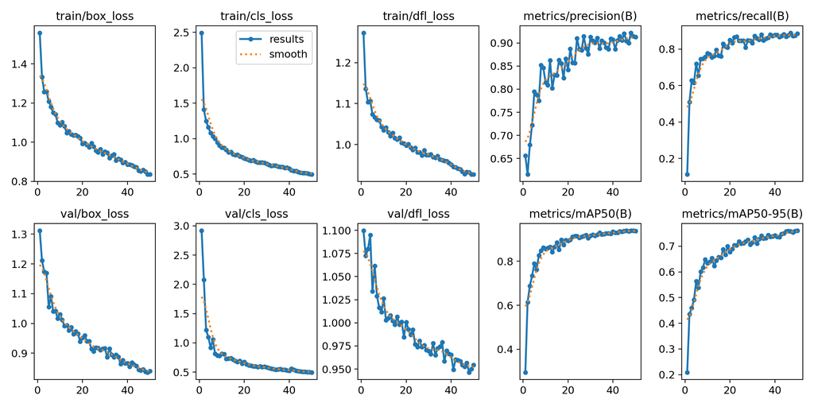

```python
from PIL import Image
import IPython.display as display

# Tampilkan hasil grafik training
display.display(Image.open("runs/detect/train/results.png"))
```

🎯 Tujuan:

Menampilkan results.png, yaitu grafik yang berisi:

- Loss training/validasi
- mAP (akurasi)
- Precision dan recall dari epoch ke epoch

✅ Loss (Train & Val)

- box_loss, cls_loss, dan dfl_loss baik pada train maupun val terus menurun, menunjukkan model belajar dengan baik dan tidak overfitting.

✅ Evaluasi (Metrics)

- Precision dan Recall meningkat stabil hingga mencapai ~0.9.
- mAP50 dan mAP50-95 juga naik konsisten, dengan mAP50 mendekati 0.95 dan mAP50-95 mendekati 0.75.

# Menghubungkan Google Drive ke Google Colab.

```python
from google.colab import drive
drive.mount('/content/drive')
```

🎯 Tujuan:

Agar Anda bisa:

- Menyimpan file hasil training ke Drive.
- Mengambil dataset atau model dari Drive.
- Backup otomatis file penting dari Colab.

# Menyalin folder hasil training ke Google Drive.

```python
!cp -r /content/runs /content/drive/MyDrive/
```

🎯 Tujuan:

Agar hasil training tersimpan aman di Google Drive, tidak hilang saat runtime Colab berakhir.

# Mengunggah file (misalnya gambar) dari komputer lokal ke Google Colab.

```python
from google.colab import files
uploaded = files.upload()  # akan muncul tombol upload, pilih file gambarnya
```

Upload widget is only available when the cell has been executed in the current browser session. Please rerun this cell to enable.

```
Saving image_1_127_jpg.rf.00427966330d7aa33b0fc23041eef76d.jpg to image_1_127_jpg.rf.00427966330d7aa33b0fc23041eef76d.jpg
```

🎯 Tujuan:

Untuk memasukkan gambar atau file lain ke lingkungan Colab agar bisa digunakan, misalnya untuk mendeteksi objek menggunakan model yang sudah dilatih.

# Mendeteksi objek pada gambar baru menggunakan model yang sudah dilatih

```python
from ultralytics import YOLO

model = YOLO("runs/detect/train/weights/best.pt")

# Contoh prediksi 1 gambar
results = model.predict(source="image_1_127_jpg.rf.00427966330d7aa33b0fc23041eef76d.jpg", save=True)
```

```
image 1/1 /content/image_1_127_jpg.rf.00427966330d7aa33b0fc23041eef76d.jpg: 640x640 4 cars, 16 motorbikes, 8.4ms
Speed: 1.8ms preprocess, 8.4ms inference, 2.5ms postprocess per image at shape (1, 3, 640, 640)
Results saved to runs/detect/predict
```

Untuk mendeteksi objek pada gambar baru menggunakan model yang sudah dilatih dan menyimpan output deteksinya.

# Menyalin folder hasil training ke Google Drive.

```python
!cp -r /content/runs /content/drive/MyDrive/
```

🎯 Tujuan:

Agar hasil training tersimpan aman di Google Drive, tidak hilang saat runtime Colab berakhir.

# Menampilkan gambar hasil prediksi deteksi objek

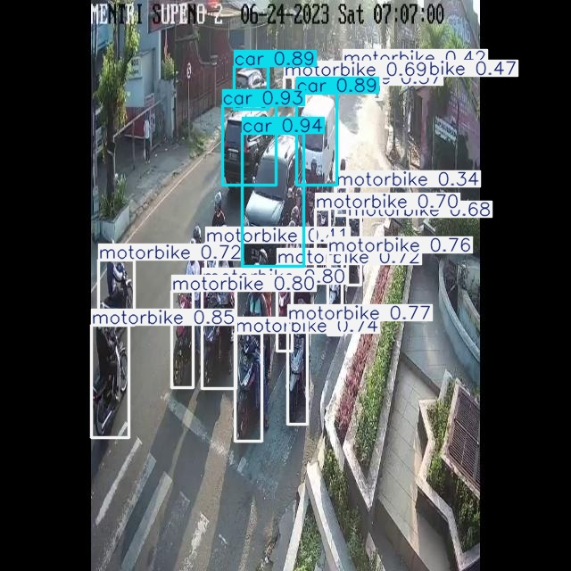

```python
from IPython.display import Image, display

image_path = '/content/drive/MyDrive/runs/detect/predict/image_1_127_jpg.rf.00427966330d7aa33b0fc23041eef76d.jpg'
display(Image(filename=image_path))
```

Digunakan untuk menampilkan gambar hasil prediksi deteksi objek di notebook Colab.

✅ Hasil Deteksi:

📈 Keakuratan:

- Sebagian besar prediksi memiliki confidence score > 0.70, menunjukkan deteksi cukup akurat.
- Beberapa motor terdeteksi dengan skor rendah (misal 0.34), bisa disebabkan overlapping atau pencahayaan.

```python
from google.colab import files
uploaded = files.upload()  # akan muncul tombol upload, pilih file gambarnya
```

Upload widget is only available when the cell has been executed in the current browser session. Please rerun this cell to enable.

```
Saving image_3_305_jpg.rf.27aa8f48a8915c3d7ce751537704d176.jpg to image_3_305_jpg.rf.27aa8f48a8915c3d7ce751537704d176.jpg
```

```python
from ultralytics import YOLO

model = YOLO("runs/detect/train/weights/best.pt")

# Contoh prediksi 1 gambar
results = model.predict(source="image_3_305_jpg.rf.27aa8f48a8915c3d7ce751537704d176.jpg", save=True)
```

```
image 1/1 /content/image_3_305_jpg.rf.27aa8f48a8915c3d7ce751537704d176.jpg: 640x640 5 cars, 8 motorbikes, 2 trucks, 9.4ms
Speed: 2.2ms preprocess, 9.4ms inference, 1.9ms postprocess per image at shape (1, 3, 640, 640)
Results saved to runs/detect/predict2
```

```python
!cp -r /content/runs /content/drive/MyDrive/
```

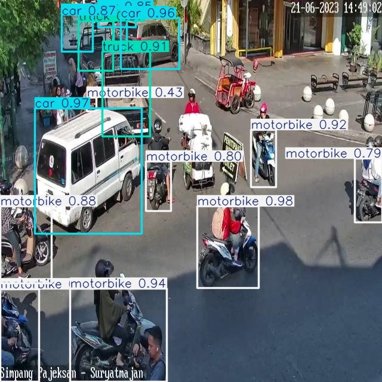

```python
from IPython.display import Image, display

image_path = '/content/drive/MyDrive/runs/detect/predict2/image_3_305_jpg.rf.27aa8f48a8915c3d7ce751537704d176.jpg'
display(Image(filename=image_path))
```

```python
result = model.predict('image_3_305_jpg.rf.27aa8f48a8915c3d7ce751537704d176.jpg')
```

```
image 1/1 /content/image_3_305_jpg.rf.27aa8f48a8915c3d7ce751537704d176.jpg: 640x640 5 cars, 8 motorbikes, 2 trucks, 10.3ms
Speed: 3.2ms preprocess, 10.3ms inference, 1.9ms postprocess per image at shape (1, 3, 640, 640)
```

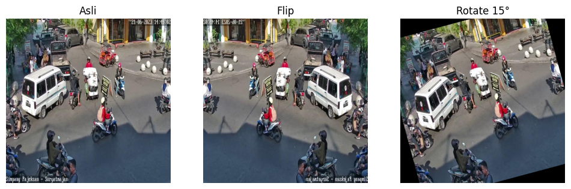

```
0: 640x640 6 cars, 7 motorbikes, 2 trucks, 26.0ms
Speed: 2.9ms preprocess, 26.0ms inference, 2.3ms postprocess per image at shape (1, 3, 640, 640)

0: 640x640 5 cars, 7 motorbikes, 2 trucks, 8.3ms
Speed: 3.1ms preprocess, 8.3ms inference, 1.8ms postprocess per image at shape (1, 3, 640, 640)

0: 640x640 3 cars, 9 motorbikes, 9.4ms
Speed: 2.3ms preprocess, 9.4ms inference, 1.8ms postprocess per image at shape (1, 3, 640, 640)
```

```python
from PIL import Image
import numpy as np
import matplotlib.pyplot as plt

# Buka gambar asli
img = Image.open('image_3_305_jpg.rf.27aa8f48a8915c3d7ce751537704d176.jpg')
img_flip = img.transpose(Image.FLIP_LEFT_RIGHT)
img_rot = img.rotate(15)

# Tampilkan semua gambar
plt.figure(figsize=(12, 4))

plt.subplot(1, 3, 1)
plt.imshow(img)
plt.title("Asli")
plt.axis('off')

plt.subplot(1, 3, 2)
plt.imshow(img_flip)
plt.title("Flip")
plt.axis('off')

plt.subplot(1, 3, 3)
plt.imshow(img_rot)
plt.title("Rotate 15°")
plt.axis('off')

plt.show()

# Konversi ke array jika perlu
img_np = np.array(img)
img_flip_np = np.array(img_flip)
img_rot_np = np.array(img_rot)

# Lakukan prediksi
res1 = model.predict(source=img_np)
res2 = model.predict(source=img_flip_np)
res3 = model.predict(source=img_rot_np)

# Kombinasikan hasil prediksi di sini sesuai kebutuhan
# Misalnya: voting klasifikasi, gabung bounding box, dst
```